# ECON 5305: Econ & Business Forecasting

# Data Translation Challenge

# McKenzie Maidl, Tuan Anh Nguyen, Samikshya Pandey

```r
# imports
library(dplyr)
library(forecast)
library(urca)
```

## Data

```r
# upload data
total_sales <- read.csv('TOTALSA.csv')
head(total_sales)
```

```
##         DATE TOTALSA
## 1 1976-01-01  39.532
## 2 1976-04-01  39.236
## 3 1976-07-01  40.029
## 4 1976-10-01  40.682
## 5 1977-01-01  44.275
## 6 1977-04-01  45.071
```

```r
# convert date into time format
total_sales$DATE <- as.Date(total_sales$DATE, format = "%d/%m/%Y")
```

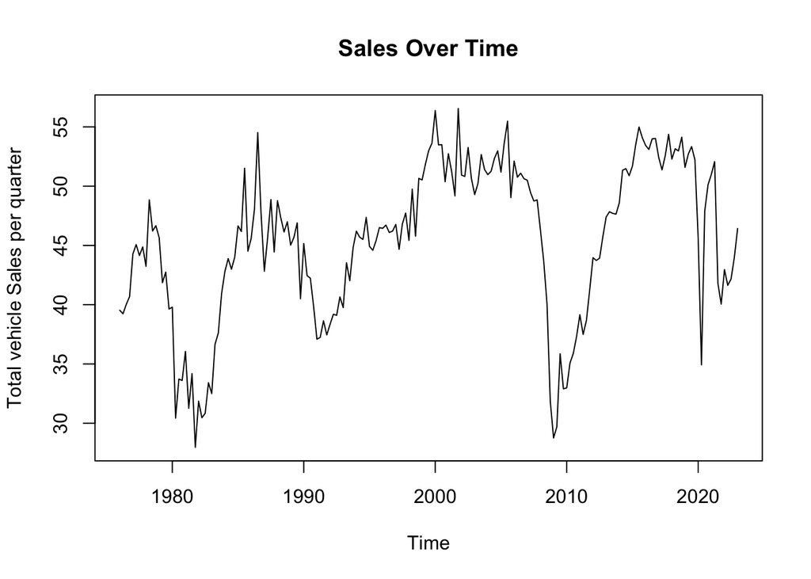

```r
# create time series
ts <- ts(total_sales$TOTALSA, start=c(1976,1),  frequency=4)
plot(ts, xlab = "Time", ylab = "Total vehicle Sales per quarter", main = "Sales Over Time")
```

```r
# check if data is stationary via the Augmented Dickey-Fuller test
summary(ur.df(ts, type="drift", lags=0))
```

```
##
## ###############################################
## # Augmented Dickey-Fuller Test Unit Root Test #
## ###############################################
##
## Test regression drift
##
##
## Call:
## lm(formula = z.diff ~ z.lag.1 + 1)
##
## Residuals:
##      Min       1Q   Median       3Q      Max
## -10.6883  -1.1853   0.3628   1.6417  11.8278
##
## Coefficients:
##             Estimate Std. Error t value Pr(>|t|)
## (Intercept)  4.91710    1.50125   3.275  0.00126 **
## z.lag.1     -0.10753    0.03274  -3.285  0.00122 **
## ---
## Signif. codes:  0 '***' 0.001 '**' 0.01 '*' 0.05 '.' 0.1 ' ' 1
##
## Residual standard error: 2.94 on 186 degrees of freedom
## Multiple R-squared:  0.05482,    Adjusted R-squared:  0.04974
## F-statistic: 10.79 on 1 and 186 DF,  p-value: 0.00122
##
##
## Value of test-statistic is: -3.2846 5.4089
##
## Critical values for test statistics:
##       1pct  5pct 10pct
## tau2 -3.46 -2.88 -2.57
## phi1  6.52  4.63  3.81
```

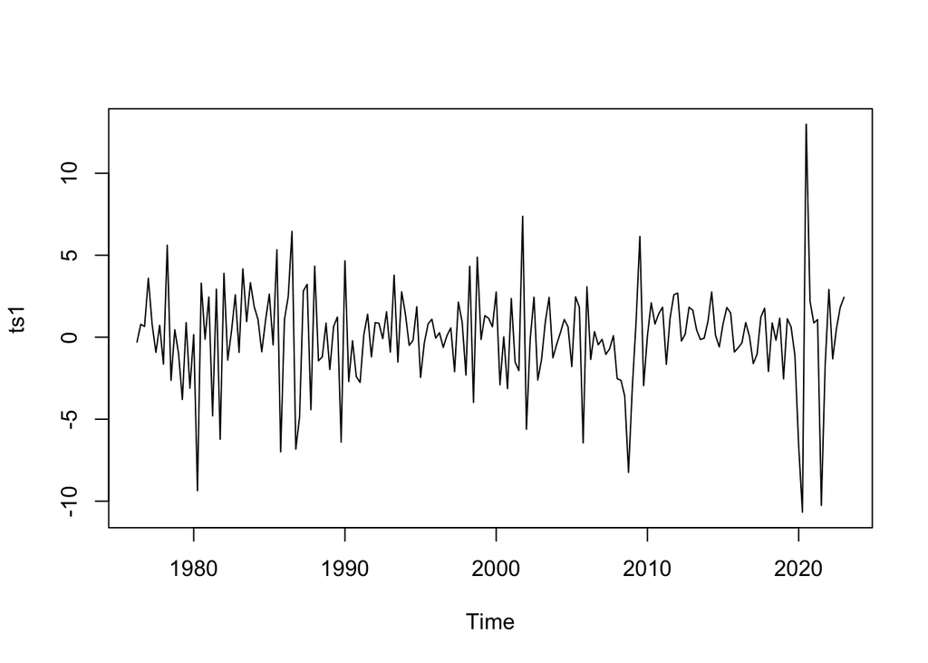

```r
# make data stationary via first difference
ts1 <- diff(ts)
plot(ts1)
```

```r
# Augmented Dickey-Fuller
summary(ur.df(ts1, type="drift", lags=0))
```

```
##
## ###############################################
## # Augmented Dickey-Fuller Test Unit Root Test #
## ###############################################
##
## Test regression drift
##
##
## Call:
## lm(formula = z.diff ~ z.lag.1 + 1)
##
## Residuals:
##      Min       1Q   Median       3Q      Max
## -12.2452  -1.0096   0.1837   1.6030  10.4873
##
## Coefficients:
##             Estimate Std. Error t value Pr(>|t|)
## (Intercept)  0.04393    0.21581   0.204    0.839
## z.lag.1     -1.23024    0.07167 -17.165   <2e-16 ***
## ---
## Signif. codes:  0 '***' 0.001 '**' 0.01 '*' 0.05 '.' 0.1 ' ' 1
##
## Residual standard error: 2.951 on 185 degrees of freedom
## Multiple R-squared:  0.6143, Adjusted R-squared:  0.6122
## F-statistic: 294.6 on 1 and 185 DF,  p-value: < 2.2e-16
##
##
## Value of test-statistic is: -17.1647 147.3162
##
## Critical values for test statistics:
##       1pct  5pct 10pct
## tau2 -3.46 -2.88 -2.57
## phi1  6.52  4.63  3.81
```

After we take the difference of the total sales, we can see that the data is stationary. This is further confirmed by the ADF test. Our ADF test statistics value is much smaller than the critical value. Therefore, we can confirm that the data is now stationary.

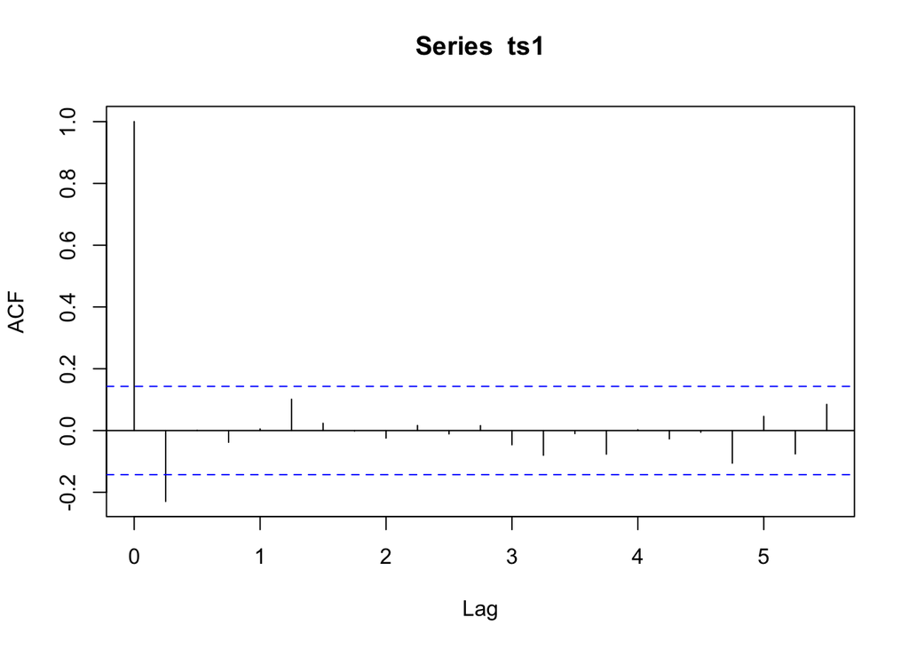

```r
# ACF and PACF plots (stationary time series)
acf(ts1)
```

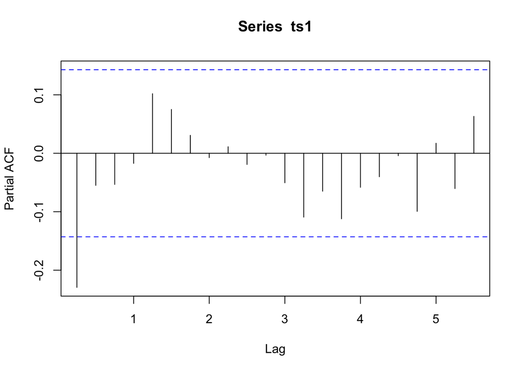

```r
pacf(ts1)
```

## Step 1: Models

```r
# create different models:
labels <- c()
r2 <- c()
aic <- c()
bic <- c()
mean_resd <- c()

for (m in c(1, 2, 3, 4, 5, 6)) {
  m1 <- arima(ts1, order=c(m, 0, 0))
  m2 <- arima(ts1, order=c(0, 0, m))
  m3 <- arima(ts1, order=c(1, 0, m))
  m4 <- arima(ts1, order=c(m, 0, m))

  # Correcting label concatenation
  labels <- c(labels, paste("AR(", m, ")", sep=""),
                      paste("MA(", m, ")", sep=""),
                      paste("ARMA(1,", m, ")", sep=""),
                      paste("ARMA(", m, ",", m, ")", sep=""))

  # Calculate R^2 and ensure both series have no NA values for valid comparison
  r2 <- c(r2, cor(fitted(m1), ts1, use = "complete.obs")^2,
              cor(fitted(m2), ts1, use = "complete.obs")^2,
              cor(fitted(m3), ts1, use = "complete.obs")^2,
              cor(fitted(m4), ts1, use = "complete.obs")^2)

  aic <- c(aic, AIC(m1), AIC(m2), AIC(m3), AIC(m4))
  bic <- c(bic, BIC(m1), BIC(m2), BIC(m3), BIC(m4))
  mean_resd <- c(mean_resd, mean(residuals(m1)),
                            mean(residuals(m2)),
                            mean(residuals(m3)),
                            mean(residuals(m4)))
}
# Creating the data frame to display results
all_models <- data.frame(labels, r2, aic, bic,mean_resd)
all_models <- all_models[!duplicated(all_models), ]
all_models
```

```
##       labels         r2      aic      bic     mean_resd
## 1      AR(1) 0.05283403 943.4648 953.1741 -3.659734e-04
## 2      MA(1) 0.05695238 942.6554 952.3647 -7.351305e-06
## 3  ARMA(1,1) 0.05707851 944.6302 957.5759  1.325626e-04
## 5      AR(2) 0.05579657 944.8821 957.8279 -2.286857e-04
## 6      MA(2) 0.05706859 944.6321 957.5778  1.140836e-04
## 7  ARMA(1,2) 0.05708135 946.6296 962.8118  1.406613e-04
## 8  ARMA(2,2) 0.05729533 948.5867 968.0054  2.414461e-04
## 9      AR(3) 0.05856616 946.3386 962.5208  1.054214e-04
## 10     MA(3) 0.05728583 946.5899 962.7721  4.338815e-04
## 11 ARMA(1,3) 0.05756859 948.5338 967.9524  3.037870e-04
## 12 ARMA(3,3) 0.12836401 942.5077 968.3993 -7.619588e-03
## 13     AR(4) 0.05885201 948.2828 967.7014  5.543571e-04
## 14     MA(4) 0.06154646 947.7995 967.2182 -2.288749e-03
## 15 ARMA(1,4) 0.07437956 947.3748 970.0299 -1.173430e-02
## 16 ARMA(4,4) 0.14564789 946.6457 979.0102 -9.558472e-03
## 17     AR(5) 0.06858948 948.3783 971.0333 -3.138358e-03
## 18     MA(5) 0.07609196 946.9259 969.5810 -5.966482e-03
## 19 ARMA(1,5) 0.08066001 948.0948 973.9864 -1.141951e-02
## 20 ARMA(5,5) 0.15636927 943.7476 982.5850  6.483581e-02
## 21     AR(6) 0.07409739 949.2988 975.1904 -5.918842e-03
## 22     MA(6) 0.07825215 948.5083 974.3999 -7.261171e-03
## 23 ARMA(1,6) 0.08065956 950.0946 979.2225 -1.143695e-02
## 24 ARMA(6,6) 0.16992683 950.9160 996.2262 -9.907775e-03
```

```r
# sort models by AIC and select top 5
sorted_by_aic <- all_models[order(all_models$aic), ]
top_5_aic <- head(sorted_by_aic, 5)
top_5_aic
```

```
##       labels         r2      aic      bic     mean_resd
## 12 ARMA(3,3) 0.12836401 942.5077 968.3993 -7.619588e-03
## 2      MA(1) 0.05695238 942.6554 952.3647 -7.351305e-06
## 1      AR(1) 0.05283403 943.4648 953.1741 -3.659734e-04
## 20 ARMA(5,5) 0.15636927 943.7476 982.5850  6.483581e-02
## 3  ARMA(1,1) 0.05707851 944.6302 957.5759  1.325626e-04
```

```r
# sort models by BIC and select the top 5
sorted_by_bic <- all_models[order(all_models$bic), ]
top_5_bic <- head(sorted_by_bic, 5)
top_5_bic
```

```
##      labels         r2      aic      bic     mean_resd
## 2     MA(1) 0.05695238 942.6554 952.3647 -7.351305e-06
## 1     AR(1) 0.05283403 943.4648 953.1741 -3.659734e-04
## 3 ARMA(1,1) 0.05707851 944.6302 957.5759  1.325626e-04
## 6     MA(2) 0.05706859 944.6321 957.5778  1.140836e-04
## 5     AR(2) 0.05579657 944.8821 957.8279 -2.286857e-04
```

Based on the value, we choose ARMA(3,3), MA(1), and R(1) because these performed best when sorted by AIC, which is better than any models sorted by BIC method. The AIC value is also acceptable and BIC vales are not that different.

The AIC and BIC for ARMA(3,3) are about 942 and 968 respectively. For MA(1) these are about 942 and 952, and for AR(1) they are 943 and 953.

### ARMA(3,3)

All ACF (except the first one) and PACF lags are within the significance lines, indicating they resemble white noise.

Given the p-value of over 0.9, we would fail to reject the null hypothesis of the Ljung-Box test, which states that the residuals are independently distributed (i.e., exhibit no autocorrelation). This is an indicator of a good model fit, as it implies that the residuals from the ARMA(3,3) model resemble white noise.

```r
# create model
model_finalarma3 <- arima(ts1, order=c(3,0,3))
summary(model_finalarma3)
```

```
##
## Call:
## arima(x = ts1, order = c(3, 0, 3))
##
## Coefficients:
##          ar1      ar2      ar3      ma1     ma2     ma3  intercept
##       1.3374  -0.4188  -0.2200  -1.6506  0.8088  0.1087     0.0353
## s.e.  0.5442   0.8391   0.4286   0.5570  0.9768  0.5537     0.1810
##
## sigma^2 estimated as 7.895:  log likelihood = -463.25,  aic = 942.51
##
## Training set error measures:
##                        ME     RMSE      MAE      MPE     MAPE      MASE
## Training set -0.007619588 2.809815 2.061936 56.57189 200.2847 0.6186228
##                      ACF1
## Training set -0.001315882
```

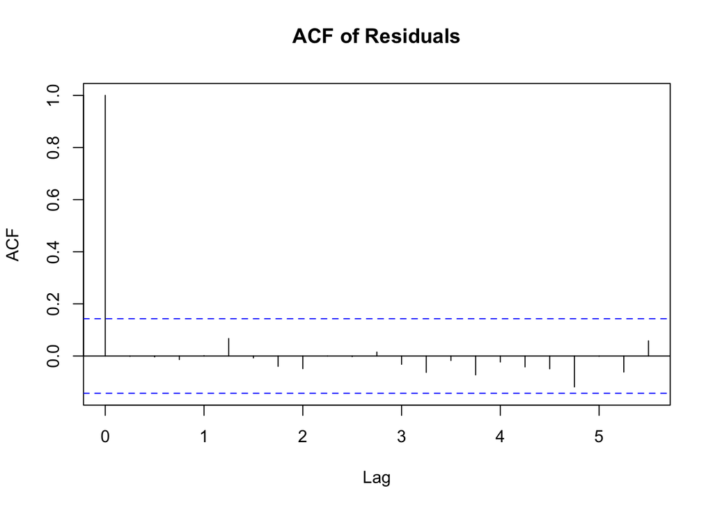

```r
# ACF and PACF of model residuals
residuals_arma3 <- residuals(model_finalarma3)
acf(residuals_arma3, main="ACF of Residuals")
```

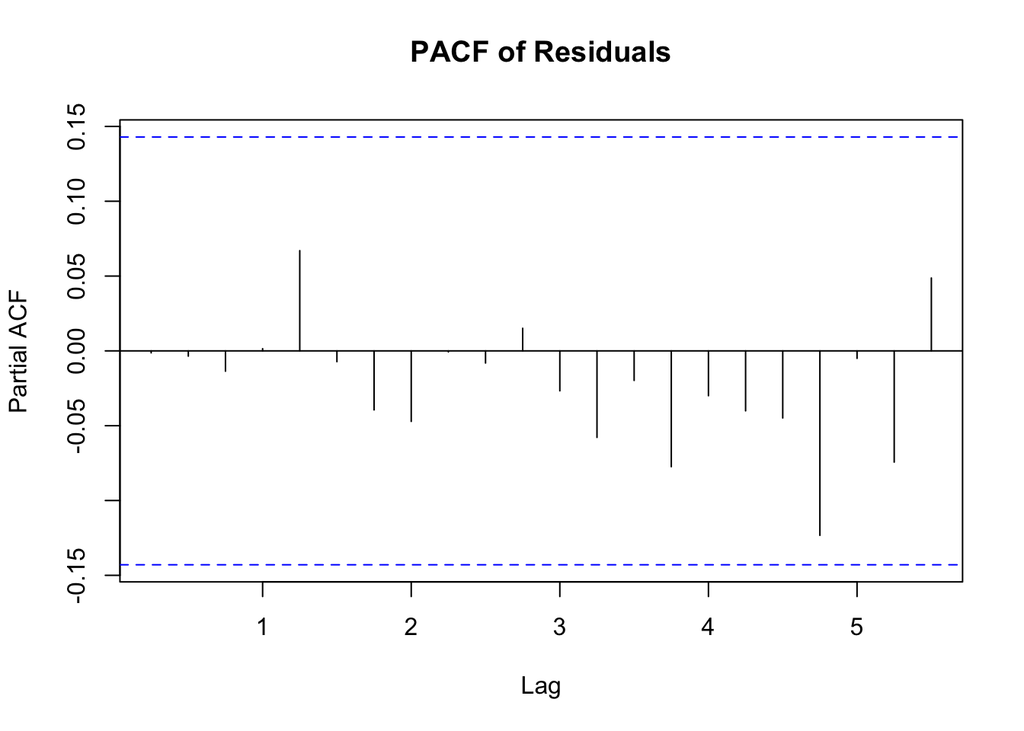

```r
pacf(residuals_arma3, main="PACF of Residuals")
```

```r
# Q-Test of the residuals to confirm they resemble white noise
ljung_box_testarma3 <- Box.test(residuals_arma3, type = "Ljung-Box", lag = 10)
print(ljung_box_testarma3)
```

```
##
##  Box-Ljung test
##
## data:  residuals_arma3
## X-squared = 1.7067, df = 10, p-value = 0.9981
```

### MA(1)

MA(1,) also has residuals that resemble white noise (p-value of 0.95), all ACF and PACF of residuals within the significance line.

```r
# create model
model_finalma1 <-  arima(ts1, order=c(0, 0, 1))
summary(model_finalma1)
```

```
##
## Call:
## arima(x = ts1, order = c(0, 0, 1))
##
## Coefficients:
##           ma1  intercept
##       -0.2481     0.0329
## s.e.   0.0715     0.1605
##
## sigma^2 estimated as 8.533:  log likelihood = -468.33,  aic = 942.66
##
## Training set error measures:
##                         ME     RMSE      MAE      MPE    MAPE      MASE
## Training set -7.351305e-06 2.921208 2.049658 72.38163 131.619 0.6149392
##                     ACF1
## Training set 0.001695766
```

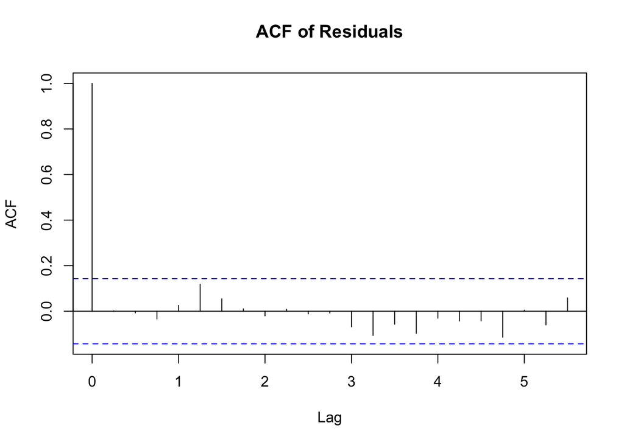

```r
# ACF and PACF of model residuals
residuals_ma1 <- residuals(model_finalma1)
acf(residuals_ma1, main="ACF of Residuals")
```

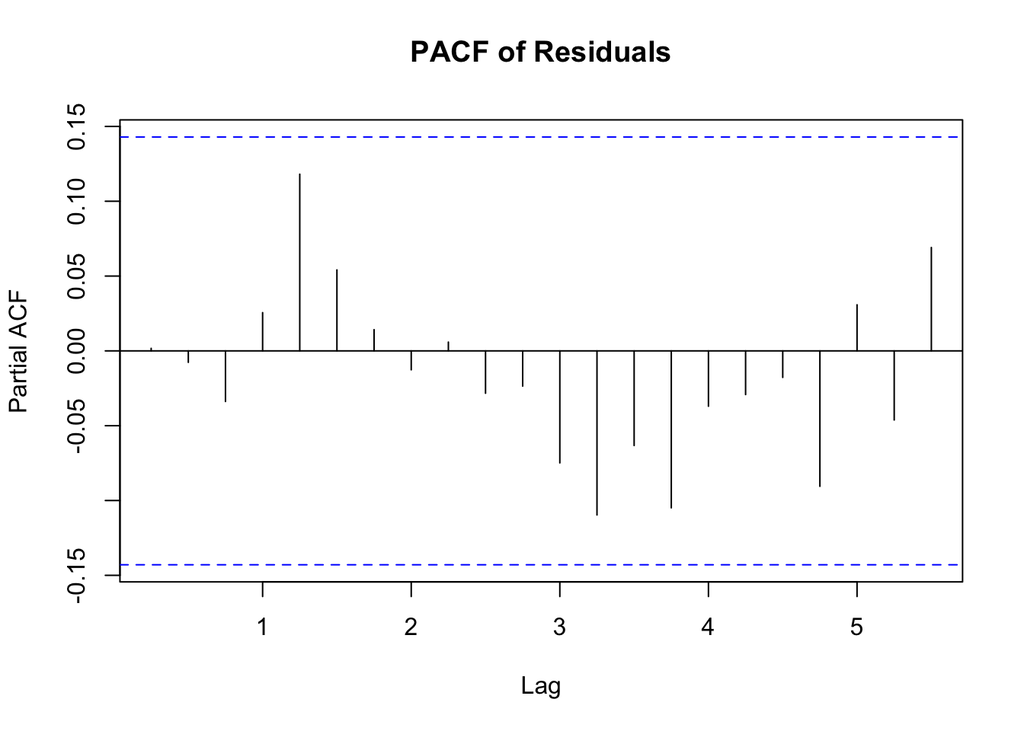

```r
pacf(residuals_ma1, main="PACF of Residuals")
```

```r
# Q-Test of the residuals to confirm they resemble white noise
ljung_box_testma1 <- Box.test(residuals_ma1, type = "Ljung-Box", lag = 10)
print(ljung_box_testma1)
```

```
##
##  Box-Ljung test
##
## data:  residuals_ma1
## X-squared = 3.8216, df = 10, p-value = 0.955
```

### AR(1)

```r
# create model
model_finalar1 <-  arima(ts1, order=c(1, 0, 0))
summary(model_finalar1)
```

```
##
## Call:
## arima(x = ts1, order = c(1, 0, 0))
##
## Coefficients:
##           ar1  intercept
##       -0.2290     0.0346
## s.e.   0.0709     0.1739
##
## sigma^2 estimated as 8.571:  log likelihood = -468.73,  aic = 943.46
##
## Training set error measures:
##                         ME     RMSE      MAE      MPE     MAPE      MASE
## Training set -0.0003659734 2.927578 2.052492 69.16183 137.7393 0.6157893
##                     ACF1
## Training set -0.01397325
```

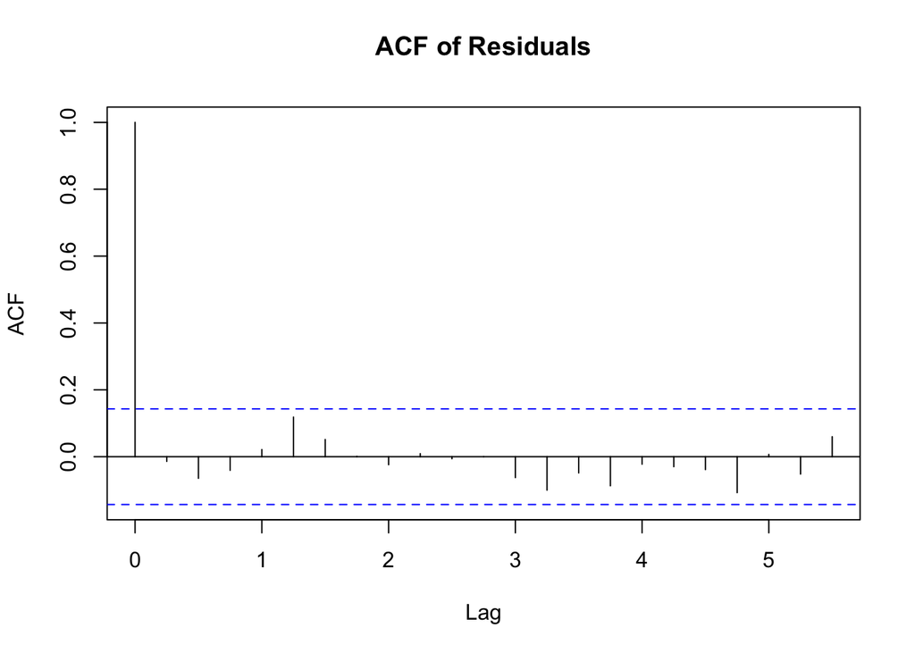

```r
# ACF and PACF of model residuals
residuals_ar1 <- residuals(model_finalar1)
acf(residuals_ar1, main="ACF of Residuals")
```

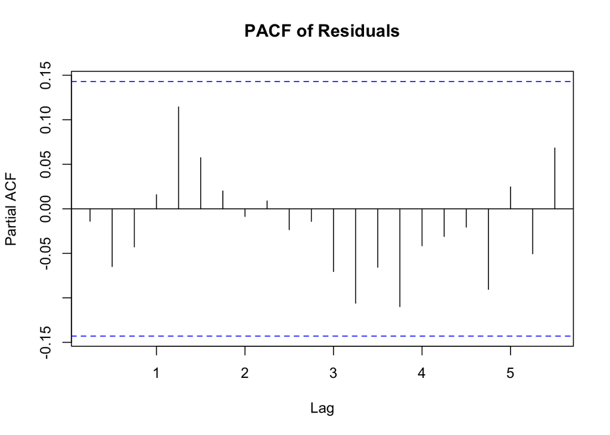

```r
pacf(residuals_ar1, main="PACF of Residuals")
```

```r
# Q-Test of the residuals to confirm they resemble white noise
ljung_box_testar1 <- Box.test(residuals_ar1, type = "Ljung-Box", lag = 10)
print(ljung_box_testar1)
```

```
##
##  Box-Ljung test
##
## data:  residuals_ar1
## X-squared = 4.6441, df = 10, p-value = 0.9136
```

## Step 1: Forecasting

### ARMA(3,3)

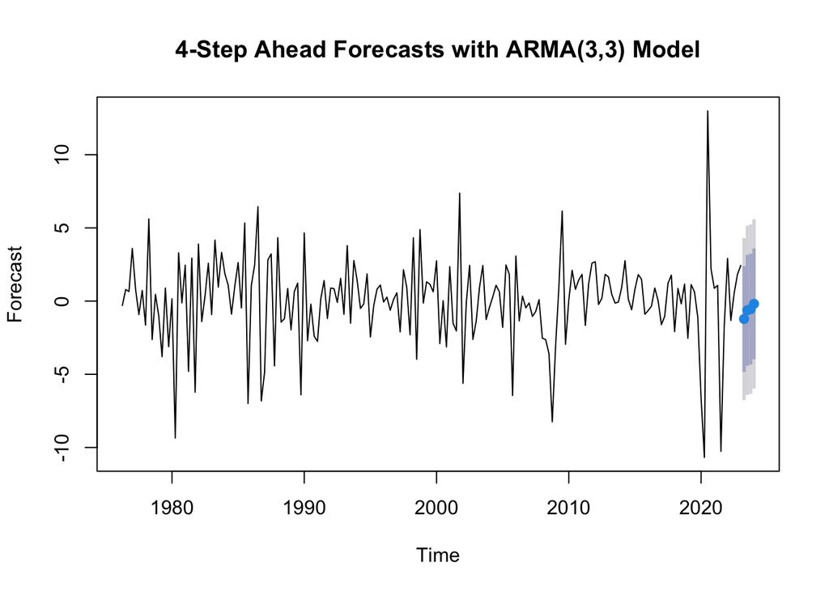

```r
forecast_arma33 <- forecast(model_finalarma3, h=4)
plot(forecast_arma33, main="4-Step Ahead Forecasts with ARMA(3,3) Model",
     xlab="Time", ylab="Forecast")
```

### MA(1)

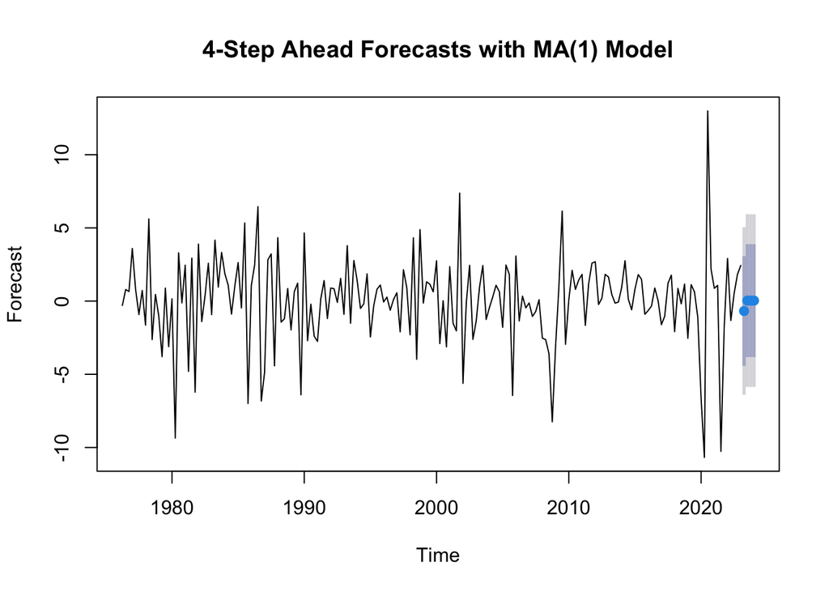

```r
forecast_ma1 <- forecast(model_finalma1, h=4)
plot(forecast_ma1, main="4-Step Ahead Forecasts with MA(1) Model", xlab="Time", ylab="Forecast")
```

### AR(1)

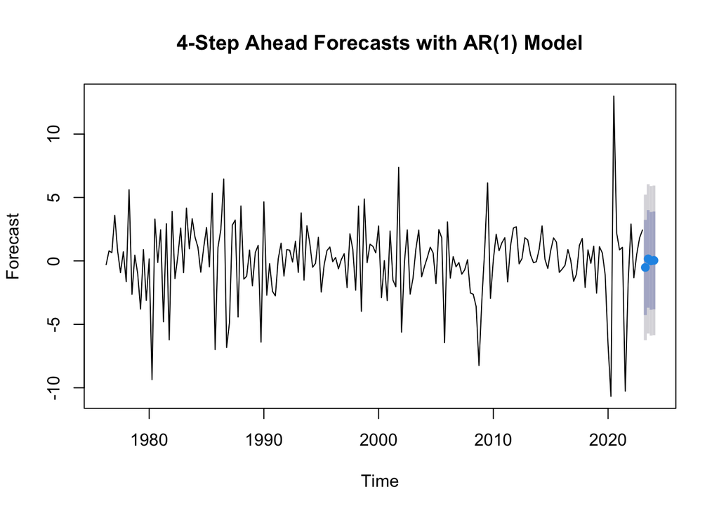

```r
forecast_ar1 <- forecast(model_finalar1, h=4)
plot(forecast_ar1, main="4-Step Ahead Forecasts with AR(1) Model", xlab="Time", ylab="Forecast")
```

## Comparing Model Performance

### Loss Comparison

#### Functions

```r
# function for measuring performance of a model forecast
measure_performance <- function(actuals, predicted, simple=FALSE) {

  # calculate error
  error <- actuals - predicted

  # Mean Percentage Error
  MPE <- round(mean(error / actuals), 4)

  # Informational Efficiency
  summ <- summary(lm(error ~ predicted))
  if (simple == TRUE) {
    t_val <- round(summ[[4]][3], 4)
    p_val <- round(summ[[4]][4], 4)
  }
  else {
    t_val <- round(summ[[4]][6], 4)
    p_val <- round(summ[[4]][8], 4)
  }
  reject <- if(p_val < 0.05) 1 else 0
  IE <- paste(t_val, p_val, reject, sep=", ")

  # Mean Squared Error
  MSE <- round(mean(error^2), 4)

  # Mean Absolute Error
  MAE <- round(mean(abs(error)), 4)

  # Mean Absolute Percentage Error
  pererror <-abs((error)/actuals)
  MAPE <- round(mean(pererror), 4)

  results <- c(MPE, IE, MSE, MAE, MAPE)
  return(results)
}
```

```r
# function for generating forecasts using different schemes
generate_forecasts <- function(ts, model, model_order, h) {

  # train/test split
  ts_train <- window(ts, end=c(2018,1))
  ts_test <- window(ts, start=c(2018,1+h))
  ntest <- length(ts_test)

  # fixed scheme
  m1 <- arima(ts_train, order=model_order)
  fcast1 <- numeric(ntest)
  for (i in 1:ntest) {
    up <- window(ts, end=c(2017,4+i))
    md <- Arima(up, model=m1)
    fcast1[i] <- forecast(md, h=h)$mean[h]
  }
  per1 <- measure_performance(ts_test, fcast1)
  per1 <- c(model, 'Fixed', per1)
  per1df <- data.frame(matrix(unlist(per1), nrow=length(1), byrow=FALSE))

  # recursive scheme
  fcast2 <- numeric(ntest)
  for (i in 1:ntest) {
    up <- window(ts, end=c(2017,4+i))
    md <- arima(up, order=model_order)
    fcast2[i] <- forecast(md, h=h)$mean[h]
  }
  per2 <- measure_performance(ts_test, fcast2)
  per2 <- c(model, 'Recursive', per2)
  per2df <- data.frame(matrix(unlist(per2), nrow=length(1), byrow=FALSE))

  # rolling scheme
  fcast3 <- numeric(ntest)
  for (i in 1:ntest) {
    up <- window(ts, start=c(1976+i,1), end=c(2017,4+i))
    md <- arima(up, order=model_order)
    fcast3[i] <- forecast(md, h=h)$mean[h]
  }
  per3 <- measure_performance(ts_test, fcast3)
  per3 <- c(model, 'Rolling', per3)
  per3df <- data.frame(matrix(unlist(per3), nrow=length(1), byrow=FALSE))

  # compare performance
  results <- data.frame(rbind(per1, per2, per3))
  colnames(results) <- c('Model', 'Scheme', 'MPE', 'IE', 'MSE', 'MAE', 'MAPE')

  return(list(results=results, forecast=fcast1))
}
```

```r
# function for generating forecasts for naive model
generate_naive_forecast <- function(ts, h) {

  # train/test split
  ts_train <- window(ts, end=c(2018,1))
  ts_test <- window(ts, start=c(2018,1+h))
  ntest <- length(ts_test)

  last_value <- tail(ts_train, 1)
  naive_forecasts <- rep(last_value, ntest)

  results <- measure_performance(ts_test, naive_forecasts, simple=TRUE)
  results <- c('Naive', 'Fixed', results)
  results <- data.frame(matrix(unlist(results), nrow=length(1), byrow=FALSE))
  colnames(results) <- c('Model', 'Scheme', 'MPE', 'IE', 'MSE', 'MAE', 'MAPE')

  return(results)
}
```

```r
# function for generating forecasts for simple average model
generate_average_forecast <- function(ts, h) {

  # train/test split
  ts_train <- window(ts, end=c(2018,1))
  ts_test <- window(ts, start=c(2018,1+h))
  ntest <- length(ts_test)

  last_four_values <- tail(ts_train, 4)
  average_forecast <- mean(last_four_values)
  average_forecasts <- rep(average_forecast, ntest)

  results <- measure_performance(ts_test, average_forecasts, simple=TRUE)
  results <- c('Simple Average', 'Fixed', results)
  results <- data.frame(matrix(unlist(results), nrow=length(1), byrow=FALSE))
  colnames(results) <- c('Model', 'Scheme', 'MPE', 'IE', 'MSE', 'MAE', 'MAPE')

  return(results)
}
```

#### Results

```r
# 1 step ahead forecast
naive_1 <- generate_naive_forecast(ts1, 1)
simple_1 <- generate_average_forecast(ts1, 1)
arma33_1 <- generate_forecasts(ts1, 'ARMA(3,3)', c(3,0,3), 1)
ma1_1 <- generate_forecasts(ts1, 'MA(1)', c(0,0,1), 1)
ar_1 <- generate_forecasts(ts1, 'AR(1)', c(1,0,0), 1)

arma33_1_results <- arma33_1$results
ma1_1_results <- ma1_1$results
ar_1_results <- ar_1$results

# combine results
r1a <- union(naive_1, simple_1)
r1b <- union(r1a, arma33_1_results)
r1c <- union(r1b, ma1_1_results)
results_1 <- union(r1c, ar_1_results)
rownames(results_1) <- NULL

# display results
results_1
```

```
##             Model    Scheme    MPE                 IE     MSE    MAE   MAPE
## 1           Naive     Fixed 1.2061  1.6109, 0.1237, 0 26.7831 3.9701  2.388
## 2  Simple Average     Fixed 1.0031  -0.2346, 0.817, 0 23.6329  3.161 1.0031
## 3       ARMA(3,3)     Fixed 1.8126 -2.5508, 0.0201, 1 32.0649 4.0842 1.8589
## 4       ARMA(3,3) Recursive 1.2483 -1.6352, 0.1194, 0 27.3286 3.5896 1.3502
## 5       ARMA(3,3)   Rolling 1.3119 -1.8625, 0.0789, 0 28.0679 3.7473 1.3575
## 6           MA(1)     Fixed 1.0763 -0.3659, 0.7187, 0 23.4502  3.257 1.0763
## 7           MA(1) Recursive 1.1078 -0.7748, 0.4485, 0 24.5204 3.3378 1.1078
## 8           MA(1)   Rolling 1.0847  -1.2314, 0.234, 0 25.5516  3.377 1.0847
## 9           AR(1)     Fixed 1.0187 -0.8891, 0.3857, 0 24.7411 3.3132 1.0187
## 10          AR(1) Recursive 1.0346 -1.1591, 0.2616, 0 25.5312 3.3641 1.0346
## 11          AR(1)   Rolling 1.0159 -1.4461, 0.1653, 0 26.1227 3.3778 1.0178
```

```r
# 2 step ahead forecast
naive_2 <- generate_naive_forecast(ts1, 2)
simple_2 <- generate_average_forecast(ts1, 2)
arma33_2 <- generate_forecasts(ts1, 'ARMA(3,3)', c(3,0,3), 2)
ar_2 <- generate_forecasts(ts1, 'AR(1)', c(1,0,0), 2)

arma33_2_results <- arma33_2$results
ar_2_results <- ar_2$results

# combine results
r2a <- union(naive_2, simple_2)
r2b <- union(r2a, arma33_2_results)
results_2 <- union(r2b, ar_2_results)
rownames(results_2) <- NULL

# display results
results_2
```

```
##            Model    Scheme    MPE                 IE     MSE    MAE   MAPE
## 1          Naive     Fixed 1.0908  1.4783, 0.1566, 0 27.7322 4.0234 2.3349
## 2 Simple Average     Fixed 1.0014 -0.2752, 0.7863, 0 24.8338 3.2799 1.0014
## 3      ARMA(3,3)     Fixed 1.5532 -2.5705, 0.0199, 1  31.205 3.9093 1.6002
## 4      ARMA(3,3) Recursive 1.3812 -2.1672, 0.0447, 1 28.4399 3.6589 1.3812
## 5      ARMA(3,3)   Rolling 1.3325 -1.4143, 0.1753, 0  27.137 3.6996 1.3325
## 6          AR(1)     Fixed  0.901  -1.5607, 0.137, 0 26.1955 3.3358 0.9366
## 7          AR(1) Recursive 0.9077  -1.538, 0.1425, 0 26.0621 3.3281 0.9484
## 8          AR(1)   Rolling 0.9102 -1.3478, 0.1954, 0 25.7483 3.2988 0.9414
```

### Combined Forecasts

#### Function

```r
# function for combined forecast
combined_forecast <- function(ts, h, fcast1, fcast2, fcast3) {

  # test data
  ts_test <- window(ts, start=c(2018,1+h))

  # Equal-Weighted Forecast (average of all)
  fcast_ew <- (fcast1 + fcast2 +fcast3)/3
  mse_ew <- mean((ts_test-fcast_ew)^2) # MSE
  mse_ew <- c('Equal-weighted Forecast', mse_ew)

  # MSE-Inversely Weighted Forecast
  weights <- c(1/mean((ts_test-fcast1)^2), 1/mean((ts_test-fcast2)^2), 1/mean((ts_test-fcast3)^2))
  fcast_mseiw <- weights[1] * fcast1 + weights[2] * fcast2 + weights[3] * fcast3
  mse_mseiw <- mean((ts_test - fcast_mseiw)^2)
  mse_mseiw <- c('MSE-inversedly-weighted Forecast', mse_mseiw)

  # OLS-Weighted Forecast (linear regression of all forecasts)
  o_wait = lm(ts_test ~ fcast1 + fcast2 +fcast3)
  fcast_ols <- o_wait$fitted.values
  mse_ols <- mean((ts_test-fcast_ols)^2)
  mse_ols <- c('OLS-weighted Forecast', mse_ols)

  # visualize results
  fcast_ols_ts <- ts(fcast_ols , start=c(2018,1+h), frequency = 4)
  plot(ts, col = "blue", main = paste("Actual vs OLS-weighted Forecast", h, "Step Ahead"))
  lines(fcast_ols_ts, col = "red")
  legend("topleft", legend = c("Original Data", "Predictions"),
         col = c("blue", "red"), lty = 1:2, pch = c(NA, 20))

  # return results
  combo_forecast_mse <- data.frame(rbind(mse_ew, mse_mseiw, mse_ols))
  colnames(combo_forecast_mse) <- c('Combination Method','Mean Squared Error')
  return(combo_forecast_mse)
}
```

### 1 Step Ahead

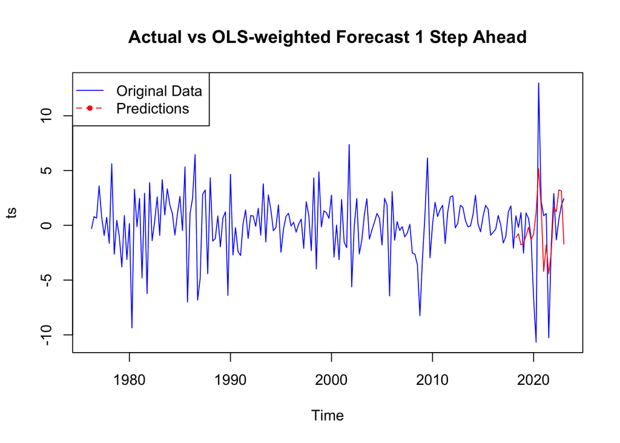

```r
# prep
ts <- ts1
h <- 1
fcast1 <- arma33_1$forecast
fcast2 <- ma1_1$forecast
fcast3 <- ar_1$forecast

# test data
ts_test <- window(ts, start=c(2018,1+h))

# Equal-Weighted Forecast (average of all)
fcast_ew <- (fcast1 + fcast2 +fcast3)/3
mse_ew <- mean((ts_test-fcast_ew)^2)
mse_ew <- c('Equal-weighted Forecast', mse_ew)

# MSE-Inversely Weighted Forecast
weights <- c(1/mean((ts_test-fcast1)^2), 1/mean((ts_test-fcast2)^2), 1/mean((ts_test-fcast3)^2))
fcast_mseiw <- weights[1] * fcast1 + weights[2] * fcast2 + weights[3] * fcast3
mse_mseiw <- mean((ts_test - fcast_mseiw)^2)
mse_mseiw <- c('MSE-inversedly-weighted Forecast', mse_mseiw)

# OLS-Weighted Forecast (linear regression of all forecasts)
o_wait = lm(ts_test ~ fcast1 + fcast2 + fcast3)
fcast_ols <- o_wait$fitted.values
mse_ols <- mean((ts_test-fcast_ols)^2)
mse_ols <- c('OLS-weighted Forecast', mse_ols)

# visualize results
fcast_ols_ts <- ts(fcast_ols , start=c(2018,1+h), frequency = 4)
plot(ts, col = "blue", main = paste("Actual vs OLS-weighted Forecast", h, "Step Ahead"))
lines(fcast_ols_ts, col = "red")
legend("topleft", legend = c("Original Data", "Predictions"),
       col = c("blue", "red"), lty = 1:2, pch = c(NA, 20))
```

```r
# print results
combo_forecast_mse <- data.frame(rbind(mse_ew, mse_mseiw, mse_ols))
colnames(combo_forecast_mse) <- c('Combination Method','Mean Squared Error')
combo_forecast_mse
```

```
##                         Combination Method Mean Squared Error
## mse_ew             Equal-weighted Forecast   26.0047638089755
## mse_mseiw MSE-inversedly-weighted Forecast   23.6128994767827
## mse_ols              OLS-weighted Forecast   17.8597039875265
```

### 2 Steps Ahead

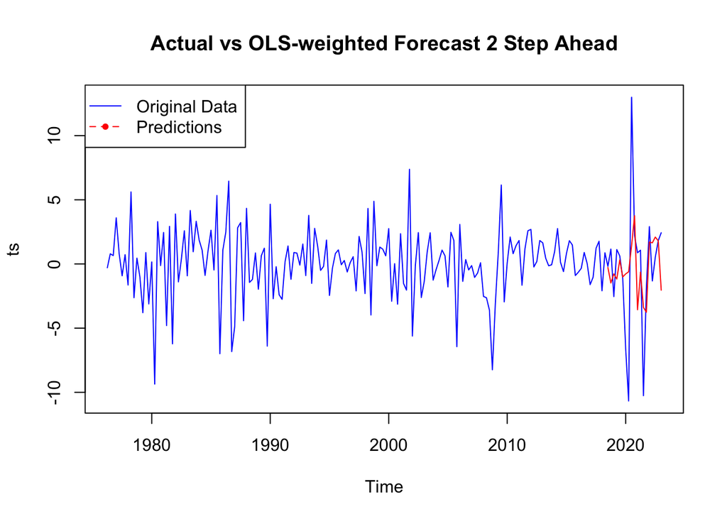

```r
# prep
ts <- ts1
h <- 2
fcast1 <- arma33_2$forecast
fcast2 <- ar_2$forecast

# test data
ts_test <- window(ts, start=c(2018,1+h))

# Equal-Weighted Forecast (average of all)
fcast_ew <- (fcast1 + fcast2)/2
mse_ew <- mean((ts_test-fcast_ew)^2)
mse_ew <- c('Equal-weighted Forecast', mse_ew)

# MSE-Inversely Weighted Forecast
weights <- c(1/mean((ts_test-fcast1)^2), 1/mean((ts_test-fcast2)^2))
fcast_mseiw <- weights[1] * fcast1 + weights[2] * fcast2
mse_mseiw <- mean((ts_test - fcast_mseiw)^2)
mse_mseiw <- c('MSE-inversedly-weighted Forecast', mse_mseiw)

# OLS-Weighted Forecast (linear regression of all forecasts)
o_wait = lm(ts_test ~ fcast1 + fcast2)
fcast_ols <- o_wait$fitted.values
mse_ols <- mean((ts_test-fcast_ols)^2)
mse_ols <- c('OLS-weighted Forecast', mse_ols)

# visualize results
fcast_ols_ts <- ts(fcast_ols , start=c(2018,1+h), frequency = 4)
plot(ts, col = "blue", main = paste("Actual vs OLS-weighted Forecast", h, "Step Ahead"))
lines(fcast_ols_ts, col = "red")
legend("topleft", legend = c("Original Data", "Predictions"),
       col = c("blue", "red"), lty = 1:2, pch = c(NA, 20))
```

```r
# print results
combo_forecast_mse <- data.frame(rbind(mse_ew, mse_mseiw, mse_ols))
colnames(combo_forecast_mse) <- c('Combination Method','Mean Squared Error')
combo_forecast_mse
```

```
##                         Combination Method Mean Squared Error
## mse_ew             Equal-weighted Forecast   28.1362085636192
## mse_mseiw MSE-inversedly-weighted Forecast    25.037484227804
## mse_ols              OLS-weighted Forecast   20.7106515309998
```